# Final Project - Credit Card Approval Random Forest Model

Adriel Kim, Peter Shin, Po Wei Tsao

12/8/2021

## Question and Background

We are CS majors, and as we were to applying to internships, we stumbled upon applying to a lot of banks and fintech companies. Because of this, we thought it would be a good idea to gain more insight on the data behind the actions that this industry works with. So we formulated the question, “What are the most important variables banks can use to determine whether or not someone is qualified for a credit card?”

## Loading the Data Set

As we can see, there is a big difference between the categories. We removed 0 and 1 to make the “paid” and “late” categories more clear-cut.

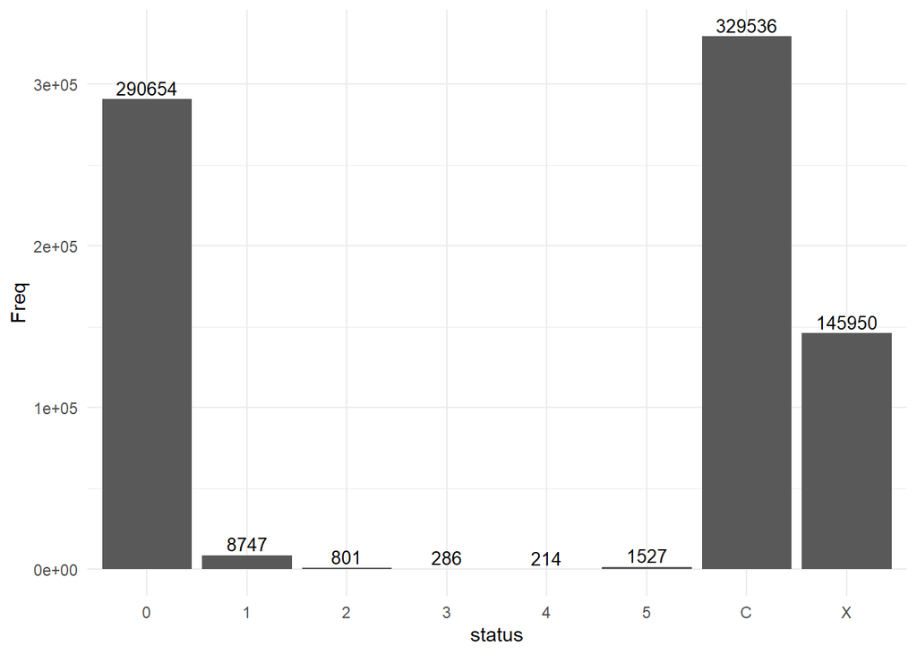

```r
#url <- "https://archive.ics.uci.edu/ml/machine-learning-databases/adult/adult.data"
data <- read_csv("application_record.csv")
data2 <- read_csv("credit_record.csv")
credit <-merge(data,data2)
status <- as.factor(credit$STATUS)
table(status)
counts = as.data.frame(table(status))
p<-ggplot(data=counts, aes(x=status, y=Freq)) +
  geom_bar(stat="identity")+
  geom_text(aes(label=Freq), vjust=-0.3, size=3.5)+
  theme_minimal()
p
```

## Variable Collapsing and Preprocessing

Throughout this project, we experimented with various ways of processing our raw data and building an effective Random Forest model. We first started by taking the entire dataset and running it through a random forest algorithm with the response variable removed. In this problem, our response variable is the status of loan-payments of each individual.

We realized that rows with the values “1” and “0” for the “STATUS” attribute were ambiguous so we decided to exclude them from our dataset for a more clear-cut division between “good” credit card holders and “bad” ones. This simplified our binary classification problem.

Furthermore, we had come to realize that the number of “paid” and “late” individuals are extremely disproportionate. There were only approximately 2800 “late” individuals while we had more than 400,000 individuals that paid on time. This would make it very difficult for the random forest model to make accurate predictions on the “late” categories. Therefore, we decided to resample the “late” and “paid” category of people an equal amount of times with replacement.

```r
set.seed(1)
creditC <- filter(credit, credit$STATUS=="C")
creditX <- filter(credit, credit$STATUS=="X")
creditC <- rbind(creditC, creditX)

creditC <- creditC[sample(nrow(creditC), 400000, replace=FALSE), ]

credit <- filter(credit, credit$STATUS!="X")
credit <- filter(credit, credit$STATUS!="0")
credit <- filter(credit, credit$STATUS!="1")
credit <- filter(credit, credit$STATUS!="C")
credit <- credit[sample(nrow(credit), 400000, replace=TRUE), ]


credit <- rbind(creditC, credit)

credit$STATUS <- fct_collapse(credit$STATUS, paid=c("C", "X"), late=c("5","3","2","4"))#paid=c("C", "X", "0", "1"), late=c("5","3","2","4"))
credit$OCCUPATION_TYPE <- replace(credit$OCCUPATION_TYPE, is.na(credit$OCCUPATION_TYPE), "Unknown")
credit <- na.omit(credit)
```

## Additional Data Preparation

Finish any other data prep (one-hot encode, reduce factor levels, drop columns)

```r
#Drop unneeded columns
credit = select(credit, -c("ID"))

#Convert columns to factors
factors <- c("CODE_GENDER","FLAG_OWN_CAR","FLAG_OWN_REALTY","OCCUPATION_TYPE", "NAME_FAMILY_STATUS", "FLAG_WORK_PHONE","FLAG_PHONE","FLAG_EMAIL","FLAG_MOBIL","NAME_EDUCATION_TYPE", "NAME_HOUSING_TYPE", "NAME_INCOME_TYPE");

credit[,factors] <- lapply(credit[,factors], as.factor)

# Remap categorical vars to have less values per cat var
credit$NAME_INCOME_TYPE <- revalue(credit$NAME_INCOME_TYPE, c("Commercial associate"="Working", "Working"="Working", "State servant"="Working", "Pensioner"="Pensioner", "Student"="Student"))
credit$NAME_HOUSING_TYPE <- revalue(credit$NAME_HOUSING_TYPE, c("House / apartment"="Apt", 'With parents'='With parents', 'Municipal apartment'='Apt','Rented apartment'='Apt','Office apartment'='Apt', 'Co-op apartment'='Apt'))
credit$NAME_EDUCATION_TYPE <- revalue(credit$NAME_EDUCATION_TYPE, c('Secondary / secondary special'='Secondary','Lower secondary'='Secondary','Higher education'='Higher education','Incomplete higher'='Higher education','Academic degree'='Academic degree'))
credit$NAME_FAMILY_STATUS <- revalue(credit$NAME_FAMILY_STATUS, c('Single / not married'='Single', 'Separated'='Single','Widow'='Single', 'Civil marriage'='Married', 'Married'='Married'))
credit$OCCUPATION_TYPE <- revalue(credit$OCCUPATION_TYPE, c('Cleaning staff'='LABOR','Cooking staff'='LABOR','Drivers'='LABOR','Laborers'='LABOR','Low-skill Laborers'='LABOR','Security staff'='LABOR','Waiters/barmen staff'='LABOR'))
credit$OCCUPATION_TYPE <- revalue(credit$OCCUPATION_TYPE, c('Accountants'='OFFICE','Core staff'='OFFICE','HR staff'='OFFICE','Medicine staff'='OFFICE','Private service staff'='OFFICE','Realty agents'='OFFICE','Sales staff'='OFFICE','Secretaries'='OFFICE'))
credit$OCCUPATION_TYPE <- revalue(credit$OCCUPATION_TYPE, c('Managers'='TECH','High skill tech staff'='TECH','IT staff'='TECH'))
# View(credit)

#one hot-encoding
credit_temp <- subset(credit, select = -STATUS)
credit_hot <- one_hot(as.data.table(credit_temp),cols = "auto",sparsifyNAs = TRUE,naCols = TRUE,dropCols = TRUE,dropUnusedLevels = TRUE)

credit_hot$STATUS = credit$STATUS
names(credit_hot) <- make.names(names(credit_hot))
```

## Create test, tune and training sets

```r
#6 Split your data into test, tune, and train. (70/15/15)
part_index_1 <- caret::createDataPartition(credit_hot$STATUS,
                                           times=1,
                                           p = 0.70,
                                           groups=1,
                                           list=FALSE)

train <- credit_hot[part_index_1, ]
tune_and_test <- credit_hot[-part_index_1, ]

#The we need to use the function again to create the tuning set

tune_and_test_index <- createDataPartition(tune_and_test$STATUS,
                                           p = .5,
                                           list = FALSE,
                                           times = 1)

tune <- tune_and_test[tune_and_test_index, ]#aka, validation set
test <- tune_and_test[-tune_and_test_index, ]#final testing set
```

## Prevalence

Our prevalence is 0.5 because we sampled ‘paid’ and ‘late’ equally.

```r
(prevalence <- table(credit$STATUS)[[2]]/length(credit$STATUS))
```

```
## [1] 0.5
```

```r
table(credit$STATUS)
```

```
##
##   late   paid
## 400000 400000
```

## Calculate the initial mtry level

```r
mytry_tune <- function(x){
  xx <- dim(x)[2]-1
  sqrt(xx)
}
mytry_tune(credit_hot)
```

```
## [1] 5.744563
```

## Run the initial RF model with 230 trees

[output not shown]

Initially, we ran the model with 500 trees. However, we realized that the error rates began to plateau at around 200 trees. For the sake of efficiency, we decided to only run our Random Forest model with 230 trees.

```
Confusion matrix:
OOB estimate of  error rate: 17.65%
       late    paid   class.error
late 229891   50109   0.1789607
paid  48716  231284   0.1739857
```

With our method of resampling, we managed to achieve an error rate of 17.65%. This is a notable improvement from the 40% error rates that we achieved without resampling. Our class error rate is also much more balanced. Before, our we had a very unbalanced class error rate (50% class error rate for “late” while a less than 2.5% class error rate for “paid”).

```r
set.seed(1)
credit_RF = randomForest(STATUS ~ .,          #<- Formula: response variable ~ predictors.
                            #   The period means 'use all other variables in the data'.
                            train,     #<- A data frame with the variables to be used.
                            #y = NULL,           #<- A response vector. This is unnecessary because we're specifying a response formula.
                            #subset = NULL,      #<- This is unnecessary because we're using all the rows in the training data set.
                            #xtest = NULL,       #<- This is already defined in the formula by the ".".
                            #ytest = NULL,       #<- This is already defined in the formula by "PREGNANT".
                            ntree = 230,        #<- Number of trees to grow. This should not be set to too small a number, to ensure that every input row gets classified at least a few times.
                            mtry = 6,            #<- Number of variables randomly sampled as candidates at each split. Default number for classification is sqrt(# of variables). Default number for regression is (# of variables / 3).
                            replace = TRUE,      #<- Should sampled data points be replaced.
                            #classwt = NULL,     #<- Priors of the classes. Use this if you want to specify what proportion of the data SHOULD be in each class. This is relevant if your sample data is not completely representative of the actual population
                            #strata = NULL,      #<- Not necessary for our purpose here.
                            sampsize = 300,      #<- Size of sample to draw each time.
                            nodesize = 5,        #<- Minimum numbers of data points in terminal nodes.
                            #maxnodes = NULL,    #<- Limits the number of maximum splits.
                            importance = TRUE,   #<- Should importance of predictors be assessed?
                            #localImp = FALSE,   #<- Should casewise importance measure be computed? (Setting this to TRUE will override importance.)
                            proximity = FALSE,    #<- Should a proximity measure between rows be calculated?
                            norm.votes = TRUE,   #<- If TRUE (default), the final result of votes are expressed as fractions. If FALSE, raw vote counts are returned (useful for combining results from different runs).
                            do.trace = TRUE,     #<- If set to TRUE, give a more verbose output as randomForest is run.
                            keep.forest = TRUE,  #<- If set to FALSE, the forest will not be retained in the output object. If xtest is given, defaults to FALSE.
                            keep.inbag = TRUE)   #<- Should an n by ntree matrix be returned that keeps track of which samples are in-bag in which trees?

credit_RF

imp_list = as.array(importance(credit_RF, type = 2, scale = TRUE))

vars = c("CODE_GENDER_F",
"CODE_GENDER_M",
"FLAG_OWN_CAR_N",
"FLAG_OWN_CAR_Y",
"FLAG_OWN_REALTY_N",
"FLAG_OWN_REALTY_Y",
"CNT_CHILDREN",
"AMT_INCOME_TOTAL",
"NAME_INCOME_TYPE_Working",
"NAME_INCOME_TYPE_Pensioner",
"NAME_INCOME_TYPE_Student",
"NAME_EDUCATION_TYPE_Academic.degree",
"NAME_EDUCATION_TYPE_Higher.education",
"NAME_EDUCATION_TYPE_Secondary",
"NAME_FAMILY_STATUS_Married",
"NAME_FAMILY_STATUS_Single",
"NAME_HOUSING_TYPE_Apt",
"NAME_HOUSING_TYPE_With.parents",
"DAYS_BIRTH",
"DAYS_EMPLOYED",
"FLAG_MOBIL_1",
"FLAG_WORK_PHONE_0",
"FLAG_WORK_PHONE_1",
"FLAG_PHONE_0",
"FLAG_PHONE_1",
"FLAG_EMAIL_0",
"FLAG_EMAIL_1",
"OCCUPATION_TYPE_OFFICE",
"OCCUPATION_TYPE_LABOR",
"OCCUPATION_TYPE_TECH",
"OCCUPATION_TYPE_Unknown",
"CNT_FAM_MEMBERS",
"MONTHS_BALANCE")
```

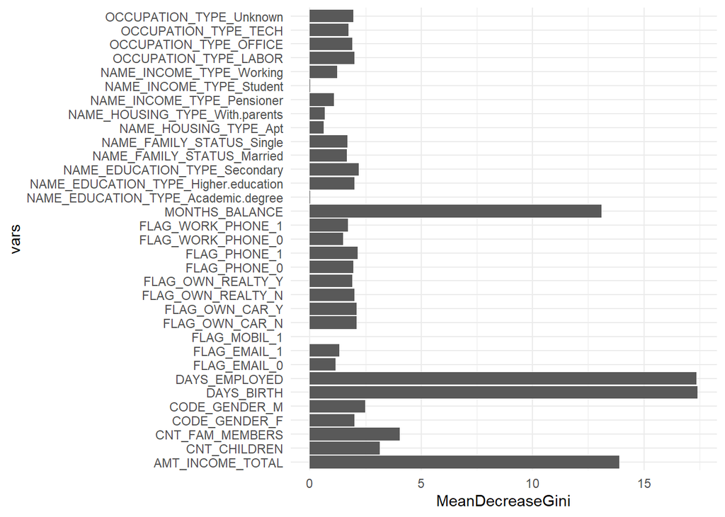

```r
imp_df = data.frame(var=vars, MeanGiniDecrease=imp_list)

p<-ggplot(data=imp_df, aes(x=MeanDecreaseGini, y=vars)) +
  geom_bar(stat="identity")+
  theme_minimal()
p
```

Most important features are CNT_CHILDREN, CNT_FAM_MEMBERS, AMT_INCOME_TOTAL, DAYS_EMPLOYED, DAYS_BIRTH, MONTHS_BALANCE.

## Model Validation Test

```r
tune_test <- function(model){
  credit_predict_tune = predict(model, tune, type="response", predict.all=FALSE, proximity = FALSE)
  (credit_eval <- confusionMatrix(as.factor(credit_predict_tune),
                as.factor(tune$STATUS),
                dnn=c("Prediction", "Actual"),
                mode = "sens_spec"))
}


tune_test(credit_RF)
```

[output not shown]

## Tuning - Finding best mtry

After evaluating our inital model on the validation set, we adjusted the mtry and sampsize hyperparameters to further refine our model. We tried multiple of mtry such as 6, 8, 10, 12, and 14. Our best results were attained with 12 with an error of 13.55% We were able to achieve around a 4% improvement.

### Final Model Result

```
No. of variables tried at each split: 12

        OOB estimate of  error rate: 13.55%
Confusion matrix:
       late   paid class.error
late 240659  39341   0.1405036
paid  36541 243459   0.1305036
```

```r
credit_RF_more_tuning = randomForest(STATUS ~ .,          #<- Formula: response variable ~ predictors.
                            #   The period means 'use all other variables in the data'.
                            train,     #<- A data frame with the variables to be used.
                            #y = NULL,           #<- A response vector. This is unnecessary because we're specifying a response formula.
                            #subset = NULL,      #<- This is unnecessary because we're using all the rows in the training data set.
                            #xtest = NULL,       #<- This is already defined in the formula by the ".".
                            #ytest = NULL,       #<- This is already defined in the formula by "PREGNANT".
                            ntree = 230,        #<- Number of trees to grow. This should not be set to too small a number, to ensure that every input row gets classified at least a few times.
                            mtry = 12,            #<- Number of variables randomly sampled as candidates at each split. Default number for classification is sqrt(# of variables). Default number for regression is (# of variables / 3).
                            replace = TRUE,      #<- Should sampled data points be replaced.
                            #classwt = NULL,     #<- Priors of the classes. Use this if you want to specify what proportion of the data SHOULD be in each class. This is relevant if your sample data is not completely representative of the actual population
                            #strata = NULL,      #<- Not necessary for our purpose here.
                            sampsize = 500,      #<- Size of sample to draw each time.
                            nodesize = 5,        #<- Minimum numbers of data points in terminal nodes.
                            #maxnodes = NULL,    #<- Limits the number of maximum splits.
                            importance = TRUE,   #<- Should importance of predictors be assessed?
                            #localImp = FALSE,   #<- Should casewise importance measure be computed? (Setting this to TRUE will override importance.)
                            proximity = FALSE,    #<- Should a proximity measure between rows be calculated?
                            norm.votes = TRUE,   #<- If TRUE (default), the final result of votes are expressed as fractions. If FALSE, raw vote counts are returned (useful for combining results from different runs).
                            do.trace = TRUE,     #<- If set to TRUE, give a more verbose output as randomForest is run.
                            keep.forest = TRUE,  #<- If set to FALSE, the forest will not be retained in the output object. If xtest is given, defaults to FALSE.
                            keep.inbag = TRUE)   #<- Should an n by ntree matrix be returned that keeps track of which samples are in-bag in which trees?

credit_RF_more_tuning


tune_test(credit_RF_more_tuning)
```

## Final Model Evaluation

Once a final model has been selected, evaluate the model using the test dataset

### Results:

```
Confusion Matrix and Statistics

          Actual
Prediction  late  paid
      late 51588  7886
      paid  8412 52114

               Accuracy : 0.8642
                 95% CI : (0.8622, 0.8661)
    No Information Rate : 0.5
    P-Value [Acc > NIR] : < 2.2e-16

                  Kappa : 0.7284

 Mcnemar's Test P-Value : 3.916e-05

            Sensitivity : 0.8598
            Specificity : 0.8686
         Pos Pred Value : 0.8674
         Neg Pred Value : 0.8610
             Prevalence : 0.5000
         Detection Rate : 0.4299
   Detection Prevalence : 0.4956
      Balanced Accuracy : 0.8642

       'Positive' Class : late
```

```r
#Best results achieved with "credit_RF_more_tuning" model with a validation accuracy of 0.8624
credit_predict_test = predict(credit_RF_more_tuning,      #<- a randomForest model
                            test,      #<- the test data set to use
                            type ="response",   #<- what results to produce, see the help menu for the options
                            predict.all = FALSE,  #<- should the predictions of all trees be kept?
                            proximity = FALSE)    #<- should proximity measures be computed

credit_eval <- confusionMatrix(as.factor(credit_predict_test),
                as.factor(test$STATUS),
                dnn=c("Prediction", "Actual"),
                mode = "sens_spec")

credit_eval
```

## Summary/Findings

To answer our question, “What are the most important variables banks can use to determine whether or not someone is qualified for a credit card?”, we can look at the results of our plot regarding variable importance. It is clear that CNT_CHILDREN, CNT_FAM_MEMBERS, AMT_INCOME_TOTAL, DAYS_EMPLOYED, DAYS_BIRTH, MONTHS_BALANCE are the most important variables. CNT_CHILDREN is the number of children the individual has. CNT_FAM_MEMBERS is the number of family members the individual has. AMT_INCOME_TOTAL is their annual income. DAYS_EMPLOYED is days since the first day of employment, if this number is negative then the person is unemployed. DAYS_BIRTH is the number of days since they were born (age). Lastly, MONTHS_BALANCE is the balance within the person’s account on the day the data was collected.